# Final Project

Roman Ahmad Zeia - 100821974

# 🏎🏁 **F1 DATA EXPLORATION**

## Introduction

This project explores various aspects of Formula 1 (F1) racing data, analyzing trends in lap times, pit stop durations, race completion statuses, constructor performance, and circuit locations. The data is processed and visualized using R, leveraging packages such as `tidyverse`, `ggplot2`, and `sf` for geospatial analysis. Below is an explanation of each analysis performed. F1 has been one of my favorite sports to watch growing up and doing this assignment felt like the right excuse to do a deep dive into F1 Analytics.

**SOURCE** This data has been pulled from [Kaggle](https://www.kaggle.com/datasets/rohanrao/formula-1-world-championship-1950-2020/data?select=races.csv) The data used in this analysis consists of multiple CSV files, each representing different aspects of F1 racing. These include information about circuits, constructors, races, drivers, and race results. The datasets are loaded into R using the `read_csv` function, enabling further analysis.

## Loading Libraries

```r
#Load all libraries required
library(tidyverse)
library(dplyr)
library(readr)
library(sf)
library(rnaturalearth)
library(rnaturalearthdata)
library(lubridate)
library(igraph)
library(ggraph)
```

## Loading Data

```r
#Load all data using read_csv function
circuits <- read_csv("data/circuits.csv")
constructor_results <- read_csv("data/constructor_results.csv")
constructor_standings <- read_csv("data/constructor_standings.csv")
constructors <- read_csv("data/constructors.csv")
driver_standings <- read_csv("data/driver_standings.csv")
drivers <- read_csv("data/drivers.csv")
lap_times <- read_csv("data/lap_times.csv")
pit_stops <- read_csv("data/pit_stops.csv")
qualifying <- read_csv("data/qualifying.csv")
races <- read_csv("data/races.csv")
results <- read_csv("data/results.csv")
seasons <- read_csv("data/seasons.csv")
sprint_results <- read_csv("data/sprint_results.csv")
status <- read_csv("data/status.csv")
```

## Analyzing Average Lap Time Over F1 History Years

One of the key performance indicators in F1 is the average lap time per race. By analyzing lap times across different years, we can observe trends in car performance, rule changes, and technological advancements.

To compute the average lap time per race, we first group lap times by race and calculate the mean. This dataset is then merged with the race data to include the corresponding year. The final step aggregates lap times per year, allowing us to analyze trends over time.

Using ggPlot we can visualize the data over a line graph and observe.

### 1995 - 2004: Lap Times Decreasing

- Aerodynamics and Tire Evolution
- Narrower cars and grooved tires introduced, faster cars as result
- Ferrari Dominance, Rapid Tech Advancements
- V10 Engines and unrestricted Aero

### 2005 - 2012: Lap Times Increased

- Regulations to slow down cars
- Swtich from V10 to V8 engines
- FIA deliberately slowed cars down with engine & aero restrictions.

### 2016 - 2017: Lap Times decreased again

- New regulations: wider cars, bigger tires, more downforce

### 2021 - 2024: Lap Times decrease

- Introduction of ground effect cars
- Teams optimize weight and downforce
- Key takeaway: Ground Effect cars

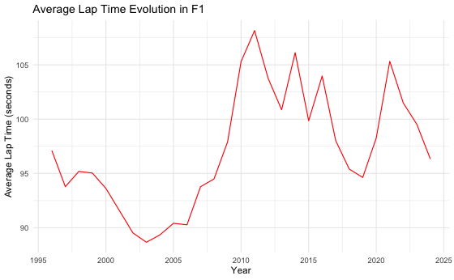

## Examining Race Finishing Statuses

Race completion statuses provide insight into common causes of race retirements and the reliability of F1 cars over time. We analyze the frequency of various finishing statuses, categorizing them into groups such as “Finished,” “Mechanical Failures,” and “Accidents/Crashes.” To create a more meaningful categorization, I classified different statuses into broader groups based on their causes. Mechanical failures include issues like engine failure and transmission problems, while accidents involve crashes and collisions. The following **pie chart** visualizes the distribution of race completion statuses:

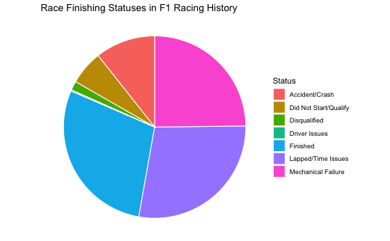

## Mapping Formula 1 Circuit Locations

F1 races take place on circuits located across the globe. Using spatial analysis, we map these locations to visualize the geographical spread of F1 circuits. The `sf` package is used to convert circuit data into a spatial format, and the `ggplot2` package plots them onto a world map.

Looking at the map below we can see a big cluster in the European region, Historically, Formula 1 circuits were predominantly in Europe, reflecting the sport’s origins and the dominance of European manufacturers and teams.

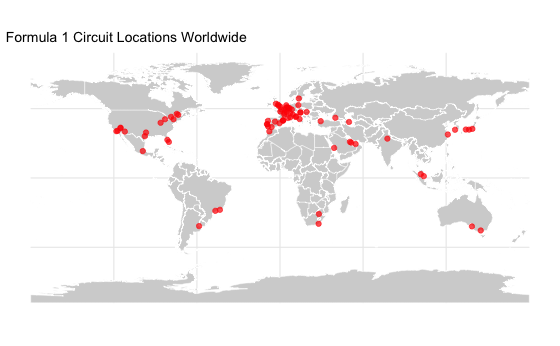

# Analyzing Pit Stop Durations Over the Years

Pit stop efficiency is a crucial factor in Formula 1, influencing race outcomes and strategic decisions. To analyze trends in pit stop performance, we calculate the average pit stop duration for each year.

First, we merge the pit stop data with the races.csv dataset to obtain corresponding years. Then, we compute the mean pit stop duration per year to identify improvements in pit crew efficiency and team strategies over time.

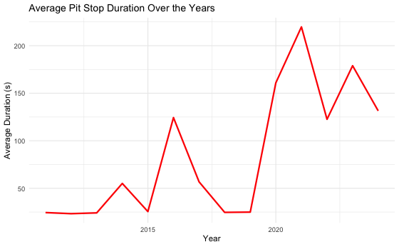

## Identifying the Most Popular Circuits

F1 races are held on circuits worldwide, but some have hosted more races than others. To determine the most frequently used circuits, we count the number of races per circuit and identify the top 10. The bar chart below visualizes the top 10 circuits with the most hosted races.

After observation we can see that the The most used Formula 1 circuit, having hosted the most Grands Prix, is the Autodromo Nazionale Monza in Italy, with 74 events. Here’s a more detailed breakdown

- Monza: Has hosted the most Formula 1 races, with a total of 74 Grands Prix.
- Circuit de Monaco: Is second, with 70 events.
- Silverstone: Is third with 59 races

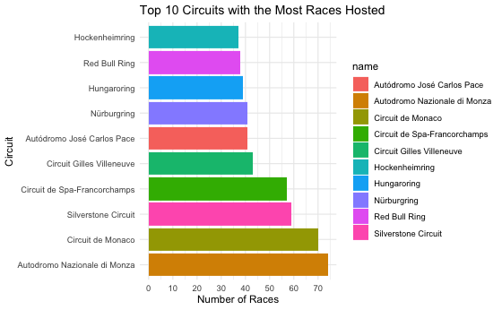

## Examining Constructor Wins Over Time

F1 constructors play a pivotal role in the sport, with some teams achieving significant dominance over the years. To analyze this, we calculate cumulative race wins for key constructors over time. The line chart below visualizes how cumulative wins have evolved for different constructors over time.

Observing the chart we can see that team Ferrari has dominance over the entire roster, This correlates strongly to the fact that Ferrari has 16 constructor titles and 15 driver titles throughout F1 History. Ferrari is by far the most successful F1 Team in the industry. Another observation we can make is Red Bull Racing’s wins, a team founded in 2005 and had grown into a disruptive force in the sport, and that can be clearly seen in the chart.

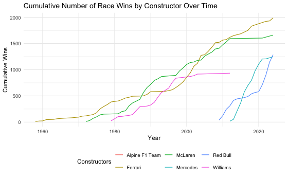

## Network Graph Of Drivers

Below is a network graph of drivers (born 1995 and after for visibility of graph). The network graph shows the drivers and the teams they have been on. One Example that can be observed below is **Charles Leclerc** racing for team **Ferrari** aswell as **Sauber** in his career. This graph can visualize how players have moved around F1 teams.

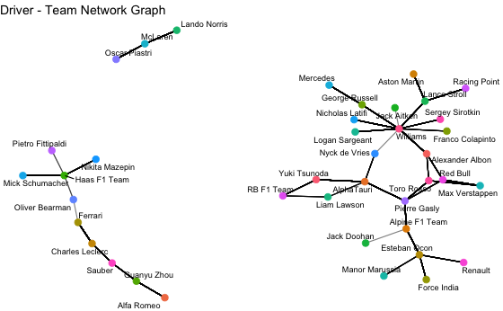